# [CoinTrip] Payer Correlation

Lin Ma

2019-10-30

### Introduction

Payer Correlation Analysis is aimed to find out the correlation between different gameplay features and if a player will become a customer/payer.

### Load Packages

```r
library(caret)
library(e1071)
library(ROCR)
library(ggplot2)
library(corrplot)
library(mice)
library(randomForest)
library(dplyr)
```

### Data Import and Cleaning

**Basic Introduction of our dataset**

Install date: Last 2 weeks

Event Date: Last 2 weeks

1. InGame Features: average/median levels, sessions, tickets, spins, puzzles, lifetree
2. Social: Friends distribution
3. Normalization of InGame Features: by active day or by session

```
 /\     /\
{  `---'  }
{  O   O  }
==>  V <==  No need for mice. This data set is completely observed.
 \  \|/  /
  `-----'

      is_customer if_fb if_liveop have_friend if_free_chest if_puzzle if_life_tree
36334           1     1         1           1             1         1            1
                0     0         0           0             0         0            0
      avg.tickets.per.session avg.levels.per.session total_friends
36334                       1                      1             1
                            0                      0             0
      avg.daily.spin.per.active.day avg.puzzles.per.session avg.spins.per.session
36334                             1                       1                     1
                                  0                       0                     0
      avg.life.tree.per.session avg.sessions.per.active.day total_sessions
36334                         1                           1              1
                              0                           0              0
      total_active_days avg.liveop.completes.per.active.day
36334                 1                                   1 0
                      0                                   0 0
```

[figure not shown]

```r
payer_correlation <- read.csv('Payer Correlation Complete v3.csv',header = TRUE)
pc <- payer_correlation[,-c(1,3)]
pc[is.na(pc)] <- 0
md.pattern(pc)
```

### Remove redundant features

We have to remove highly correlated variables so that we can prepare clean data for the later regression modeling.

```r
#Remove redundant features
set.seed(234)
correlationMatrix <- cor(pc[,8:18])
highlycorrelated<-findCorrelation(correlationMatrix,cutoff = 0.75)
print(highlycorrelated)
```

```
[1] 1
```

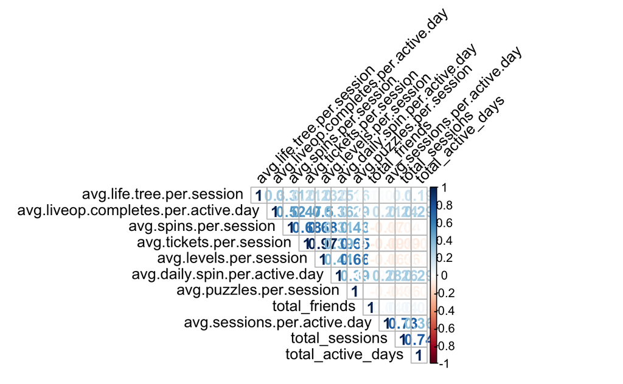

```r
#Correlation
corrplot(correlationMatrix,method = "number",type="upper",tl.col = "black",tl.srt = 45,order = "hclust")
```

**Conclusion**

Since the correlation between avg.tickets.per.session and avg.levels.per.session is far over 0.75 obviously, we will keep avg.tickets.per.session only in this case. Because avg.tickets.per.session can better help us understand the detail of player’s activity.

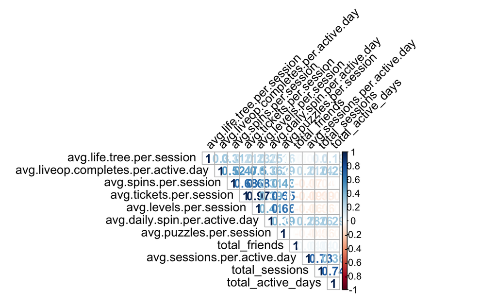

```r
corrplot(correlationMatrix,method = "number",type="upper",tl.col = "black",tl.srt = 45,order = "hclust")

set.seed(234)
findCorrelation(cor(pc[,8:17]),cutoff = 0.75)
```

```
integer(0)
```

## Split Dataset

```r
set.seed(123)
trainIndex <- createDataPartition(pc$is_customer, p=0.7, list = FALSE)
train <- pc[trainIndex,]
test <- pc[-trainIndex,]
```

## Logistic Regression

```r
set.seed(1224)
control<-trainControl(method = "repeatedcv",number=10,repeats = 3)
model_glm<-train(is_customer~.,data = train ,method='glm',preProcess=c('scale','center'),family="binomial",trControl=control)
```

[output not shown]

```r
summary(model_glm)
```

```
Call:
NULL

Deviance Residuals:
    Min       1Q   Median       3Q      Max
-5.0554  -0.2031  -0.0767  -0.0300   3.9770

Coefficients:
                                    Estimate Std. Error z value Pr(>|z|)
(Intercept)                         -5.56338    0.14988 -37.119  < 2e-16 ***
`if_fbnot fb`                       -0.23790    0.06488  -3.667 0.000246 ***
if_liveopplayed_liveop               0.32922    0.12168   2.706 0.006819 **
have_friendWith_Friends              0.18585    0.04157   4.470 7.81e-06 ***
if_free_chestplayed_free_chest       0.67267    0.13110   5.131 2.88e-07 ***
if_puzzleplayed_puzzle               0.10230    0.10643   0.961 0.336444
if_life_treeplayed_lifetree          0.31644    0.06884   4.596 4.30e-06 ***
avg.tickets.per.session              0.05309    0.06449   0.823 0.410343
total_friends                       -0.10603    0.17118  -0.619 0.535658
avg.daily.spin.per.active.day        0.51331    0.09004   5.701 1.19e-08 ***
avg.puzzles.per.session             -0.05235    0.07252  -0.722 0.470443
avg.spins.per.session                0.05143    0.03621   1.420 0.155481
avg.life.tree.per.session            0.01518    0.04975   0.305 0.760306
avg.sessions.per.active.day          0.20066    0.06086   3.297 0.000978 ***
total_sessions                      -0.03923    0.05805  -0.676 0.499213
total_active_days                    0.18955    0.06744   2.811 0.004945 **
avg.liveop.completes.per.active.day  0.01499    0.04673   0.321 0.748432
---
Signif. codes:  0 ‘***’ 0.001 ‘**’ 0.01 ‘*’ 0.05 ‘.’ 0.1 ‘ ’ 1

(Dispersion parameter for binomial family taken to be 1)

    Null deviance: 4320.8  on 25433  degrees of freedom
Residual deviance: 3457.2  on 25417  degrees of freedom
AIC: 3491.2

Number of Fisher Scoring iterations: 9
```

```r
predictions<-predict(model_glm,newdata = test,type="raw")
confusionMatrix(predictions,test$is_customer)
```

```
Confusion Matrix and Statistics

           Reference
Prediction  Non-Payer Payer
  Non-Payer     10714   180
  Payer             4     2

               Accuracy : 0.9831
                 95% CI : (0.9805, 0.9855)
    No Information Rate : 0.9833
    P-Value [Acc > NIR] : 0.5787

                  Kappa : 0.0202

 Mcnemar's Test P-Value : <2e-16

            Sensitivity : 0.99963
            Specificity : 0.01099
         Pos Pred Value : 0.98348
         Neg Pred Value : 0.33333
             Prevalence : 0.98330
         Detection Rate : 0.98294
   Detection Prevalence : 0.99945
      Balanced Accuracy : 0.50531

       'Positive' Class : Non-Payer
```

- From the result of the logistic regression model, it’s not hard to find out even though the accuracy and sensitivity of the model is pretty high, the model overall is performing very bad since only 1% of the payers is correctly predicted as payers.
- The reason could come from the sample size, since we only have around 600 payers records in total compared with 30000 total players.
- However, we do find out some features of high significance in this model, which we could do an exploratory analysis later. For example, ‘if_fb’,‘have_friend’,‘if_free_chest’,‘if_life_tree’,‘avg.daily.spin.per.active.day’,‘avg.sessions.per.active.day’